# Tidyverse Certification

Sample Exam

[Marly Gotti](https://www.marlygotti.com) — edited by jean prado

## Instructions

1. This exam covers material from R for Data Science (https://r4ds.had.co.nz/). If you have any questions about scope, please get in touch - we’d be happy to clarify.
2. You may use any books or online resources you want during this examination, but you may not communicate with any person other than your examiner.
3. You are required to use the RStudio IDE for this exam. You may use either the desktop edition or rstudio.cloud as you prefer.
4. You may do your work in an R script or an R Markdown file, and may use one for the whole exam or one for each question as your prefer. Whichever you choose, you must send your final work to the examiner by email upon completion of the examination.
5. Please let the examiner know when you finish each part of each question so that they can check your work.

## Question 1

The file at_health_facilities.csv contains a tidy dataset with four columns:

- The ISO3 code of the country that reported data.
- The year for which data was reported.
- The percentage of HIV-positive children born to HIV-positive mothers age 15–17.
- The percentage of HIV-positive children born to HIV-positive mothers age 20–34.

Please answer the following questions:

1. How many countries reported data?

```r
health_facilities <- readr::read_csv("https://education.rstudio.com/blog/2020/02/instructor-certification-exams/at_health_facilities.csv") |>
  janitor::clean_names()
health_facilities |>
  dplyr::distinct(iso3) |>
  nrow()
```

```
## [1] 100
```

2. What is the difference between the minimum and maximum year with valid data for each country?

```r
health_facilities |>
  dplyr::mutate(
    dplyr::across(tidyselect::starts_with("age_"),
                  ~ dplyr::na_if(.x, "-"))
  ) |>
  dplyr::filter(
    !is.na(age_15_17), !is.na(age_20_34)
  ) |>
  dplyr::group_by(iso3) |>
  dplyr::summarise(diff = max(year) - min(year))
```

```
## # A tibble: 100 x 2
##    iso3   diff
##    <chr> <dbl>
##  1 AFG       0
##  2 ALB       3
##  3 ARG       0
##  4 ARM      10
##  5 AZE       0
##  6 BDI       5
##  7 BEN      10
##  8 BFA       7
##  9 BGD       8
## 10 BIH       5
## # ... with 90 more rows
```

3. How many countries reported data in 3 or more years?

```r
health_facilities |>
  janitor::clean_names() |>
  dplyr::mutate(
    dplyr::across(tidyselect::starts_with("age_"),
                  ~ dplyr::na_if(.x, "-"))
  ) |>
  dplyr::group_by(iso3) |>
  dplyr::distinct(year) |>
  dplyr::summarise(yr_count = dplyr::n()) |>
  dplyr::filter(yr_count >= 3) |>
  nrow()
```

```
## [1] 34
```

4. Which countries reported 100% incidence for at least one year in either age group?

```r
health_facilities |>
  dplyr::filter(age_15_17 == 100 | age_20_34 == 100) |>
  dplyr::distinct(iso3) |> nrow()
```

```
## [1] 18
```

## Question 2

A student has sent you the file rmd-country-profile.Rmd, which is an R Markdown document analyzing the data in at_health_facilities.csv for Bangladesh. They could not knit the file, and are providing you with the raw .Rmd file instead of a rendered file.

1. Go through the file, fixing things that are preventing it from knitting cleanly.

```r
# download.file("https://education.rstudio.com/blog/2020-01-20-instructor-certification-exams/rmd-country-profile.Rmd", destfile = "rmd-country-profile.Rmd")
```

> The primary error is at line 3 so there’s some syntax error at the `yaml` section. The `output` part is missing a `:`.

> Moreover, there can’t be two chunks with the same name, so we’ll change the two `plot` to `plot_1` and `plot_2`.

> Another error is at line 9 which the `knitr::opts_chunk` function is with a `get` parameter but it should be `set`.

> The csv file does not existe at the currently directory, so we’ve added a line to download the file and create it explicitly.

> Lastly, the operator for ggplot at `plot_1` should be `+` and not `%>%`.
2. Change the two lines of bold text to H2-level headers to organize the document, and add a table of contents.

> Using `toc: true` and `##` instead of `**`.
3. Convert this R Markdown report for Bangladesh into a parameterized report with the country’s iso3 code as its parameter. Knit a new country profile for Egypt (ISO3 code “EGY”).

> As explained [here](https://rmarkdown.rstudio.com/lesson-6.html), we should use the `params` field within the YAML header, and called it `country` with default value `BGD`. Also added the `params$country` instead of the country name in string at line 43.

> For knitting, you have to use `rmarkdolwn::render("rmd-country-profile.Rmd", params = list(country = "EGY"))` or the “Knit with Parameters…” option below “Knit” in RStudio.

## Question 3

Your task is to turn this into a tidy data table for further analysis:

1. Describe what columns a tidy layout for this data would have and why.

> A tidy layout would have each variable within its own column, each observation within each row, and each value within its cell. This doesn’t happen on the dataset because the column have both the year and estimated *values*, that should be in each row in a separate variable.
2. Write a function that takes the name of a file containing this table as input and returns a tidy version of the table.
   - The function should replace all `-` and `>95%` values with `NA`.
   - The body of the function may contain one or more pipelines and may create temporary or intermediate variables, but may not contain any loops.

```r
tidy_infant_hiv <- function(filename) {
  raw <- readr::read_csv(file = filename)

  df <- raw |>
    tidyr::pivot_longer(cols = -ISO3, names_to = "variables", values_to = "value") |>
    tidyr::separate(variables, into = c("year", "stat"), sep = " ") |>
    dplyr::mutate(value = dplyr::na_if(value, "-"),
                  value = dplyr::na_if(value, ">95%"),
                  value = stringr::str_remove_all(value, "%"),
                  value = as.numeric(value))

  return(df)
}

tidy_infant_hiv("https://education.rstudio.com/blog/2020/02/instructor-certification-exams/infant_hiv.csv")
```

```
## # A tibble: 5,184 x 4
##    ISO3  year  stat  value
##    <chr> <chr> <chr> <dbl>
##  1 AFG   2009  est      NA
##  2 AFG   2009  hi       NA
##  3 AFG   2009  lo       NA
##  4 AFG   2010  est      NA
##  5 AFG   2010  hi       NA
##  6 AFG   2010  lo       NA
##  7 AFG   2011  est      NA
##  8 AFG   2011  hi       NA
##  9 AFG   2011  lo       NA
## 10 AFG   2012  est      NA
## # ... with 5,174 more rows
```

## Question 4

The file ranking.csv contains two columns:

- The ID of an item being rated.
- A rating, which is one of “negative”, “positive”, “indifferent”, or “wtf” (meaning the respondent didn’t understand the question).

There are multiple ratings for each item. The plot below shows this data:

- Each dot represents one item i.
- The size of the circles shows the total number of ratings for item i.
- The X coordinate for item i is the percentage of ratings for that item that are “negative”.
- The Y coordinate for item i is the percentage of ratings for that item that are “positive”.
- The regression line is created using the ‘lm’ method.

Re-create [this plot](https://education.rstudio.com/blog/2020/02/instructor-certification-exams/figs/ranking-scatterplot-1.png) using the tidyverse and ggplot2, fixing any mistakes you notice along the way.

```r
ranking <- readr::read_csv("https://education.rstudio.com/blog/2020/02/instructor-certification-exams/ranking.csv")
```

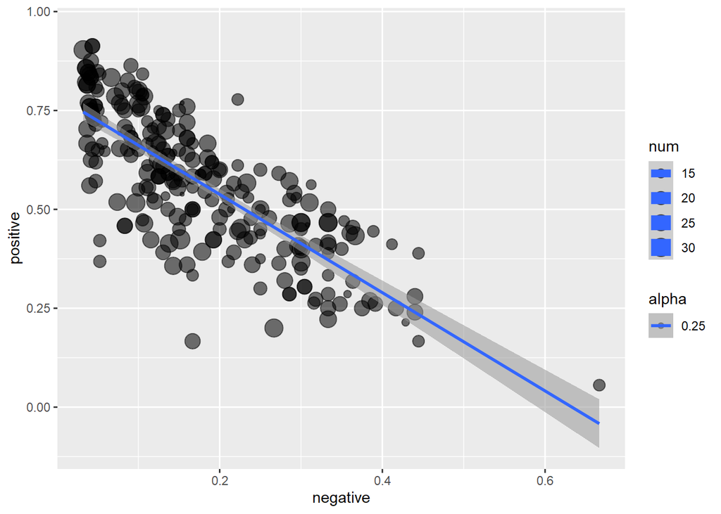

```r
ranking |>
  dplyr::group_by(item) |>
  dplyr::count(rank) |>
  tidyr::pivot_wider(names_from = rank, values_from = n) |>
  dplyr::mutate(num = sum(dplyr::across(indifferent:negative), na.rm = TRUE),
                dplyr::across(indifferent:negative, ~ . / num)) |>
  ggplot2::ggplot(
    ggplot2::aes(negative, positive, size = num, alpha = 0.25)
  ) +
  ggplot2::geom_point() + ggplot2::geom_smooth(method = "lm")
```